# ggfun: Utilities and Extensions for ggplot2

Guangchuang Yu

2026-07-02

`ggfun` collects small but useful extensions for `ggplot2`. The package focuses on tools that make it easier to style plots, add custom geometric layers, work with legends, and inspect or modify existing plot objects.

This vignette groups the functions by the type of task they solve.

## Theme Elements

### Rounded rectangles

`element_roundrect()` works like `element_rect()`, but draws rounded rectangle backgrounds. It can be used in theme elements such as facet strips, legends, panel backgrounds, and plot backgrounds.

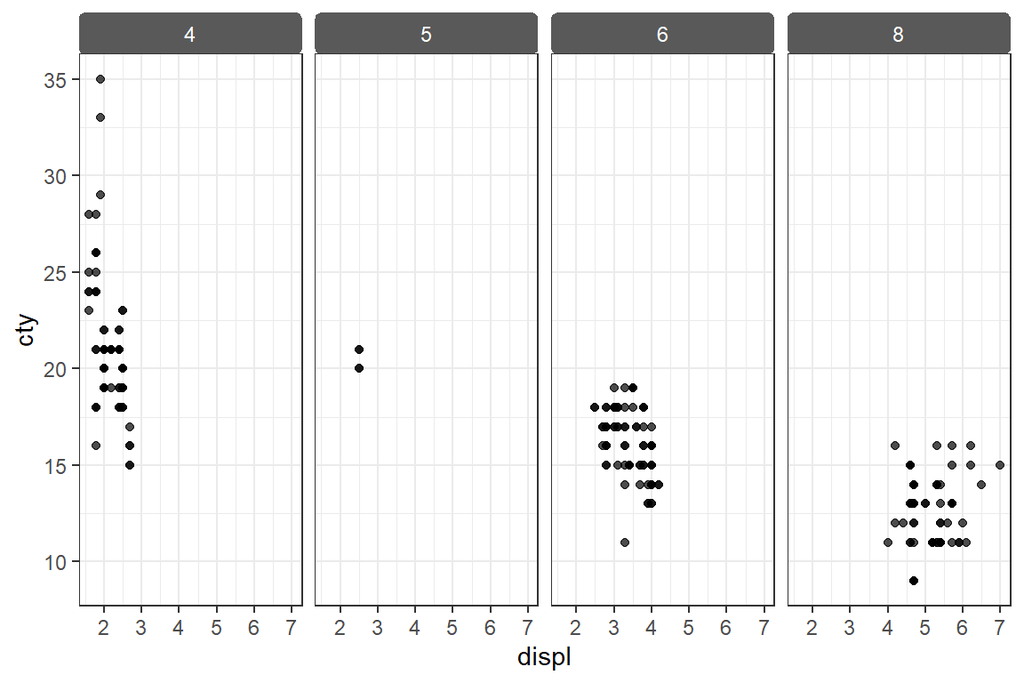

```r
p <- ggplot(mpg, aes(displ, cty)) +
  geom_point(alpha = 0.7) +
  facet_grid(cols = vars(cyl))

p + theme(
  strip.background = element_roundrect(
    fill = "grey35",
    color = NA,
    r = 0.15
  ),
  strip.text = element_text(color = "white")
)
```

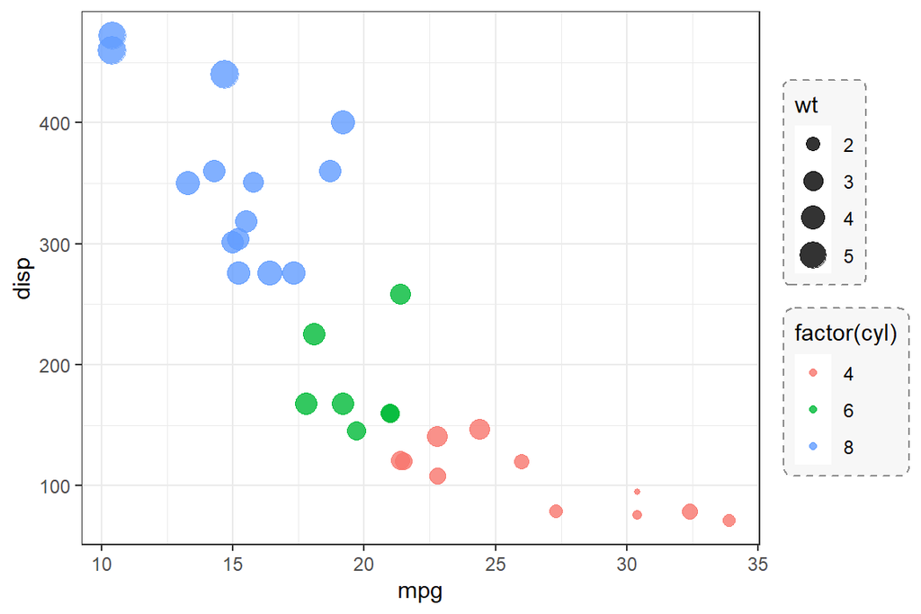

```r
ggplot(mtcars, aes(mpg, disp, color = factor(cyl), size = wt)) +
  geom_point(alpha = 0.8) +
  theme(
    legend.background = element_roundrect(
      fill = "grey97",
      color = "grey55",
      linetype = 2,
      r = 0.08
    )
  )
```

### Alternating grid bands

`element_blinds()` and `theme_blinds()` draw alternating bands on major grid lines. This is useful when categorical axes need more visual separation.

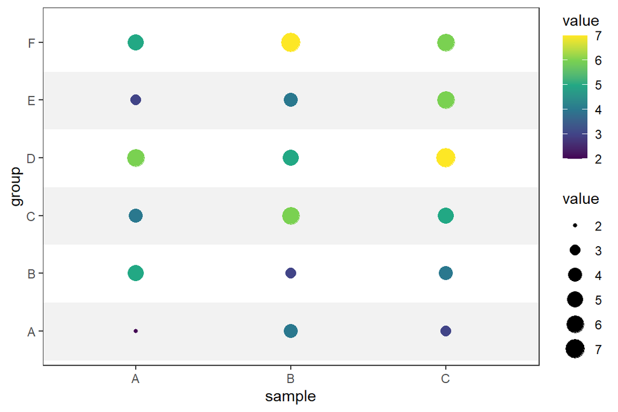

```r
df_blinds <- data.frame(
  group = rep(LETTERS[1:6], each = 3),
  sample = rep(c("A", "B", "C"), 6),
  value = c(2, 4, 3, 5, 3, 4, 4, 6, 5, 6, 5, 7, 3, 4, 6, 5, 7, 6)
)

ggplot(df_blinds, aes(sample, group)) +
  geom_point(aes(size = value, color = value)) +
  scale_color_viridis_c() +
  theme_blinds(axis = "y", colour = c("grey95", "white")) +
  theme(panel.grid.major.x = element_blank())
```

### Minimal plot backgrounds

Several small theme helpers remove common plot decorations.

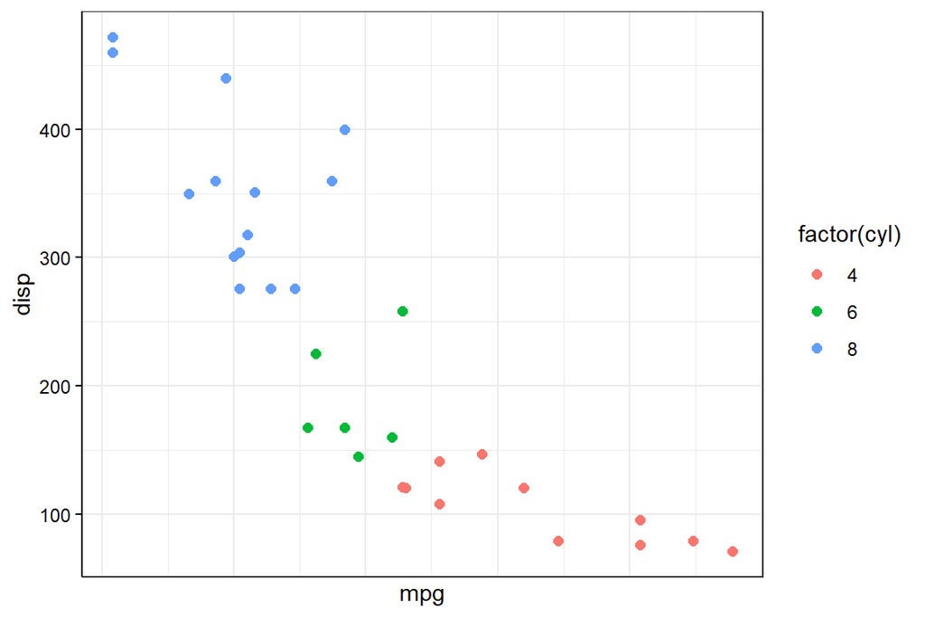

```r
ggplot(mtcars, aes(mpg, disp)) +
  geom_point(aes(color = factor(cyl)), size = 2) +
  theme_noxaxis()
```

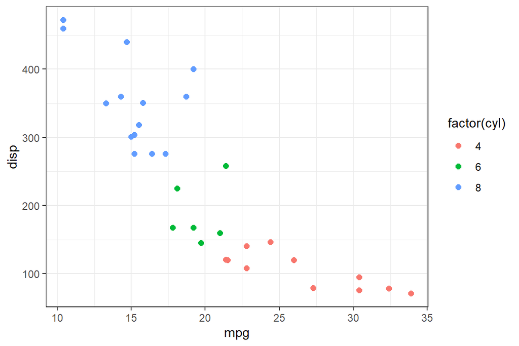

```r
ggplot(mtcars, aes(mpg, disp)) +
  geom_point(aes(color = factor(cyl)), size = 2) +
  theme_transparent()
```

## Geometric Layers

### Histograms based on `hist()`

`geom_hist()` uses `hist()` to compute break midpoints and counts. This makes it useful when the goal is to reproduce base R histogram calculations inside a `ggplot2` layer.

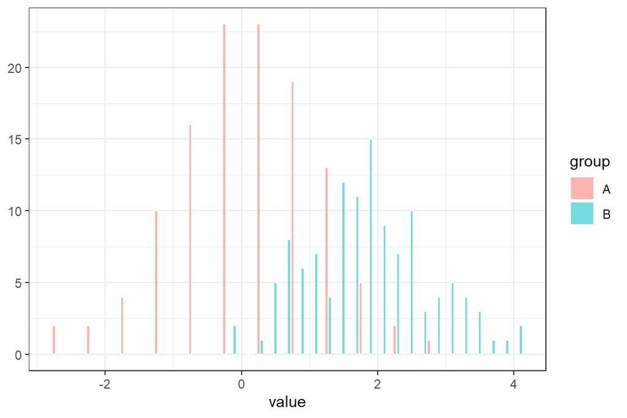

```r
set.seed(42)
df_hist <- data.frame(
  value = c(rnorm(120), rnorm(120, mean = 2)),
  group = rep(c("A", "B"), each = 120)
)

ggplot(df_hist, aes(value, fill = group)) +
  geom_hist(breaks = 16, position = "identity", alpha = 0.55, color = "white")
```

### X-splines

`geom_xspline()` draws an X-spline through control points. Positive `shape` values produce smoother curves, while negative values pull the curve toward the control points.

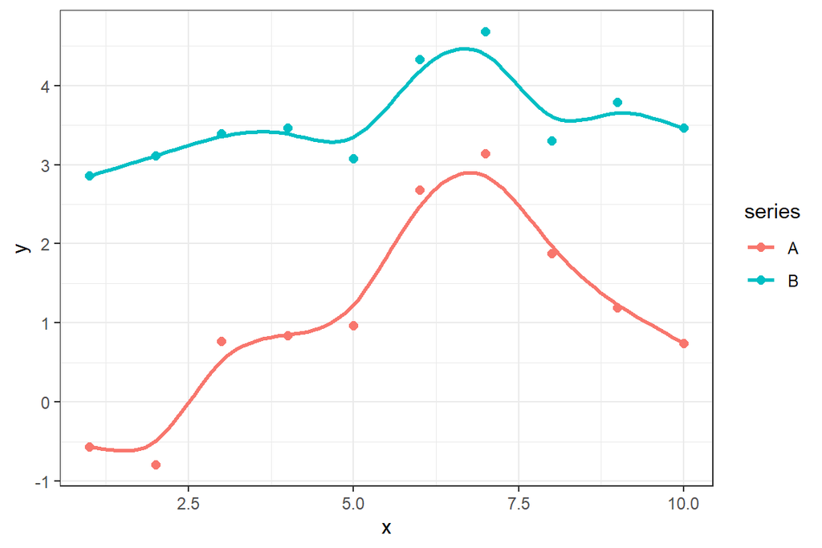

```r
set.seed(123)
df_line <- data.frame(
  x = rep(1:10, 2),
  y = c(cumsum(rnorm(10)), cumsum(rnorm(10, sd = 0.7)) + 2),
  series = rep(c("A", "B"), each = 10)
)

ggplot(df_line, aes(x, y, color = series, group = series)) +
  geom_point(size = 2) +
  geom_xspline(linewidth = 1, shape = 1)
```

### Continuous-color segments

`geom_segment_c()` draws line segments whose colors transition from `col0` to `col1`.

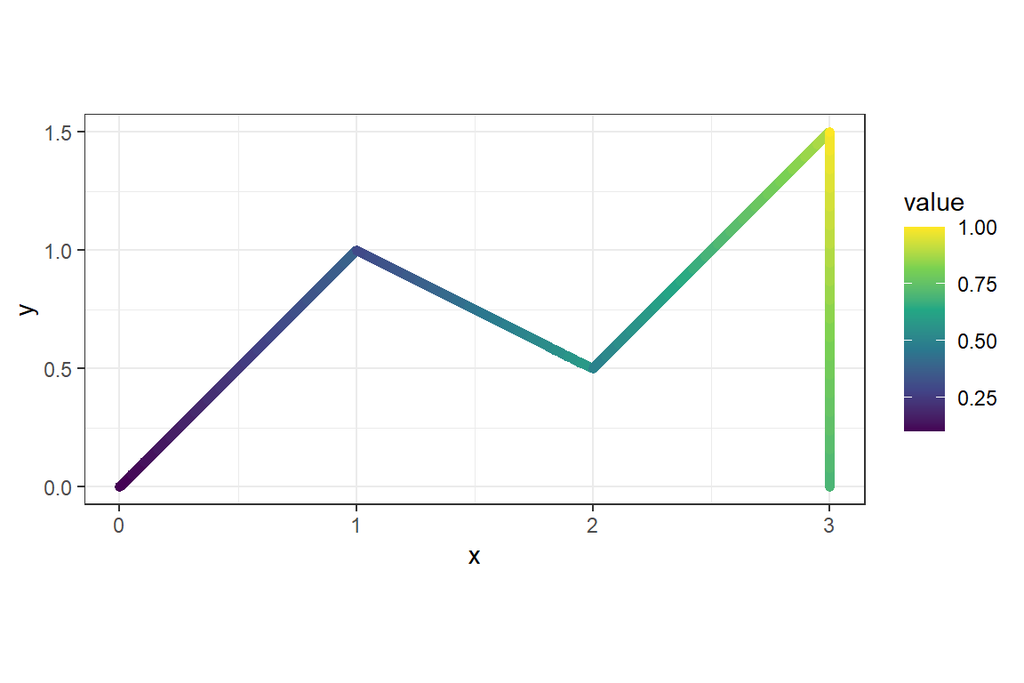

```r
df_segments <- data.frame(
  x = c(0, 1, 2, 3),
  xend = c(1, 2, 3, 3),
  y = c(0, 1, 0.5, 0),
  yend = c(1, 0.5, 1.5, 1.5),
  start = c(0.1, 0.3, 0.5, 0.7),
  end = c(0.4, 0.6, 0.9, 1.0)
)

ggplot(df_segments) +
  geom_segment_c(
    aes(x = x, y = y, xend = xend, yend = yend, col0 = start, col1 = end),
    linewidth = 2,
    lineend = "round"
  ) +
  scale_color_viridis_c(name = "value") +
  coord_equal()
```

### Shape-like point layers

`geom_scatter_rect()`, `geom_triangle()`, and `geom_cake()` are convenient when a plot needs custom glyph-like markers.

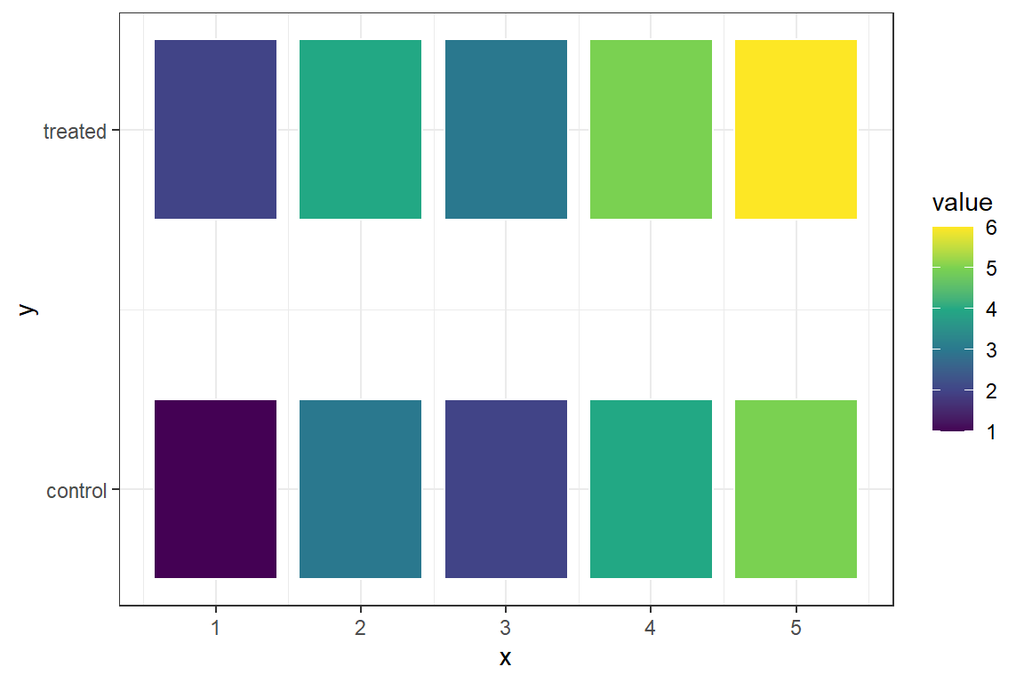

```r
df_rect <- data.frame(
  x = rep(1:5, 2),
  y = rep(1:2, each = 5),
  value = c(1, 3, 2, 4, 5, 2, 4, 3, 5, 6)
)

ggplot(df_rect, aes(x, y)) +
  geom_scatter_rect(aes(fill = value), width = 0.85, height = 0.5, color = "white") +
  scale_y_continuous(breaks = 1:2, labels = c("control", "treated")) +
  scale_fill_viridis_c()
```

[figure not shown]

```r
df_glyph <- data.frame(
  x = 1:4,
  y = c(1, 2, 1.4, 2.4),
  angle = c(0, 45, 90, 135),
  cake_size = c(0.18, 0.2, 0.16, 0.22)
)

ggplot(df_glyph, aes(x, y)) +
  geom_triangle(aes(angle = angle), fill = "tomato", size = 16, alpha = 0.8) +
  geom_cake(aes(y = y + 0.45, size = cake_size), colour.cake = "pink") +
  coord_equal(xlim = c(0.5, 4.5), ylim = c(0.5, 3.2)) +
  theme_noaxis()
```

## Facets and Plot Data

### Updating facet labels

`facet_set()` can relabel existing facets or add a simple facet strip to a plot.

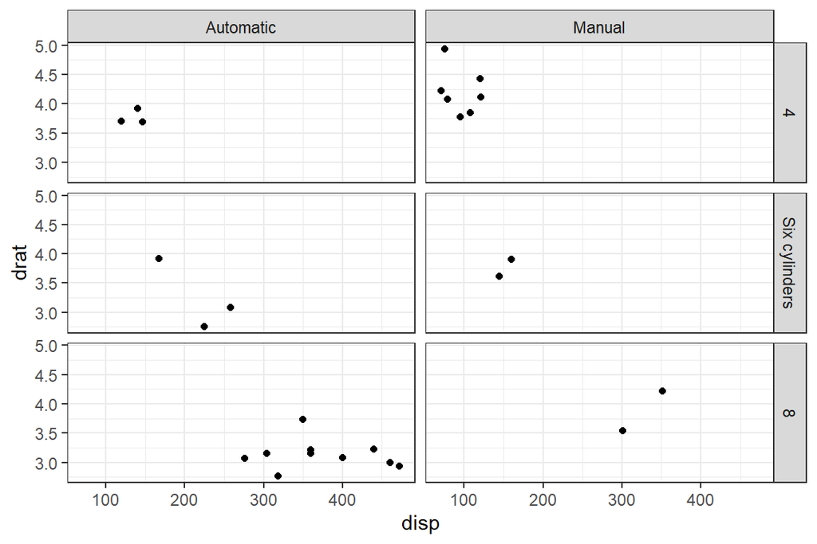

```r
p_facet <- ggplot(mtcars, aes(disp, drat)) +
  geom_point() +
  facet_grid(cols = vars(am), rows = vars(cyl))

p_facet + facet_set(label = c(`0` = "Automatic", `1` = "Manual", `6` = "Six cylinders"))
```

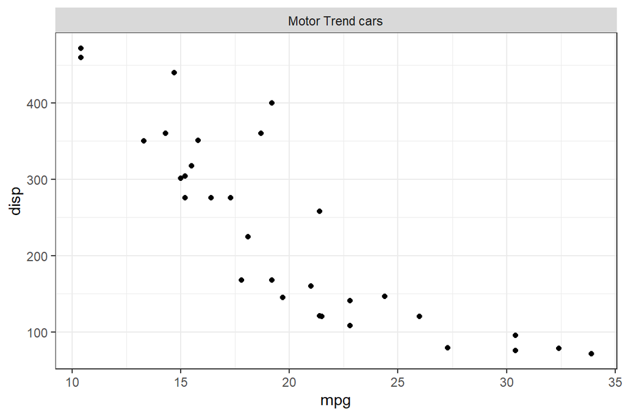

```r
ggplot(mtcars, aes(mpg, disp)) +
  geom_point() +
  facet_set("Motor Trend cars")
```

### Extracting mapped data

`get_aes_var()` returns the variable used by a mapping, and `get_plot_data()` extracts variables from the data associated with a plot or layer.

```r
p_data <- ggplot(mtcars, aes(mpg, disp, color = factor(cyl))) +
  geom_point()

get_aes_var(p_data$mapping, "x")
```

```
#> [1] "mpg"
```

```r
head(get_plot_data(p_data, var = c("x", "y")))
```

```
#>                    mpg disp
#> Mazda RX4         21.0  160
#> Mazda RX4 Wag     21.0  160
#> Datsun 710        22.8  108
#> Hornet 4 Drive    21.4  258
#> Hornet Sportabout 18.7  360
#> Valiant           18.1  225
```

`xrange()`, `yrange()`, and `ggrange()` summarize the visible data range of a plot.

```r
xrange(p_data)
```

```
#> [1]  9.225 35.075
```

```r
yrange(p_data)
```

```
#> [1]  51.055 492.045
```

```r
ggrange(p_data, var = "x", region = "plot", type = "range")
```

```
#> [1] 10.4 33.9
```

## Legends and Fonts

`get_legend()` extracts the legend grob from a plot.

```r
p_legend <- ggplot(mtcars, aes(mpg, disp, color = factor(cyl))) +
  geom_point(size = 2)

legend <- get_legend(p_legend)
class(legend)
```

```
#> [1] "gtable" "gTree"  "grob"   "gDesc"
```

`gglegend()` adds a manual legend by drawing an invisible helper layer.

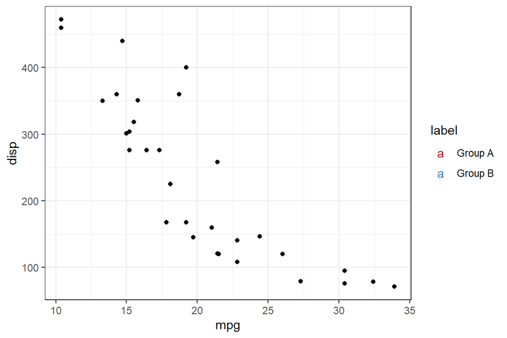

```r
p_base <- ggplot(mtcars, aes(mpg, disp)) +
  geom_point()

legend_data <- data.frame(
  colour = c("firebrick", "steelblue"),
  label = c("Group A", "Group B")
)

gglegend(aes(colour = label, label = label), legend_data, geom_text, p_base)
```

`set_font()` edits text grobs after a plot has been converted to a gtable. It draws the result and returns the edited grob invisibly.

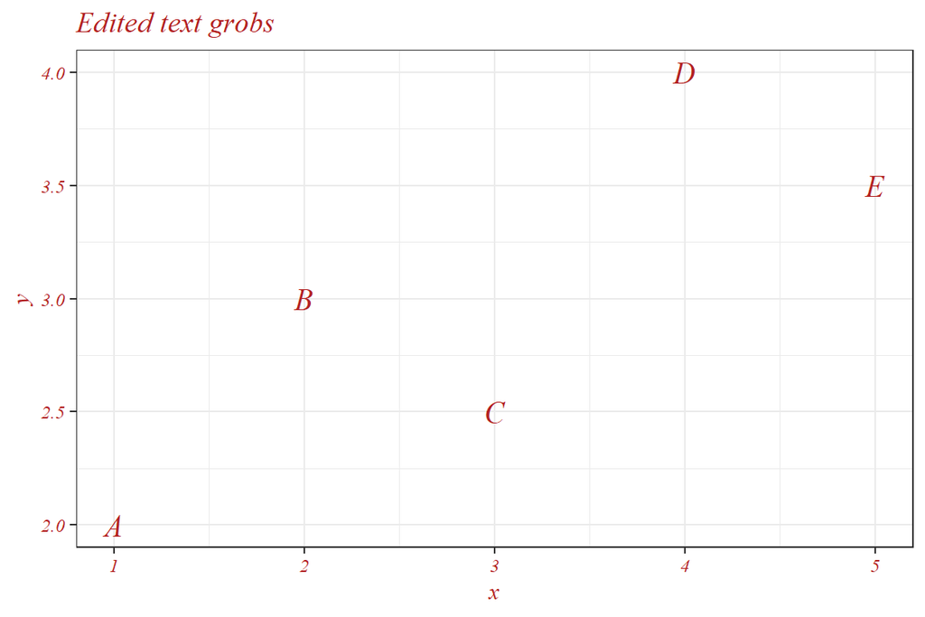

```r
df_text <- data.frame(
  x = 1:5,
  y = c(2, 3, 2.5, 4, 3.5),
  label = LETTERS[1:5]
)

p_text <- ggplot(df_text, aes(x, y, label = label)) +
  geom_text(size = 5) +
  labs(title = "Edited text grobs")

set_font(p_text, family = "serif", fontface = "italic", color = "firebrick")
```

## Summary

The functions in `ggfun` are intentionally small and composable. They are most useful when a plot is almost complete but needs a custom theme element, a specialized layer, a modified facet strip, or access to the data and grobs that `ggplot2` builds internally.